# Simple Regression & Exploratory Analysis

Pablo Rodriguez

1/17/2020

# Restoring cadmium contaminated soils using *Eremochloa ophiuroideas*

It was of interest to study the detoxifying capacity of *Eremochloa ophiuroides* in Cd contaminated soils.

### Experimental Design:

20 pots of soil with this grass were assigned 5 different dosis of Cd (60, 120, 180, 240 and 300 mg Cd per kg)

Each dose of Cd was assigned 4 pots.

After 36 days in the greenhouse accumalated Cd was measured in the plant as: Cd per kg of dried plant weight.

Model Description:

A linear relationship is suspected. The Response Variable (RV) is accumalated Cd. The Explanatory Variable (EV) which is Cd dosage is the deterministic part of the analysis. All statistic models have an error (E) asociated with them and is called the stocastic part of the analysis and it contemplates the: 1) inherent aleatory process 2) The effect of other EV not included in the model and 3) measuring error. This error is assigned a probability distribution and in this case it is assigned a normal distribution since the RV is a continuos variable.

### Firstly

I will view the data and observe the mean, median and minimums and maximums.

```r
Dosage = c(
  60, 60, 60, 60,
  120, 120, 120, 120,
  180, 180, 180, 180,
  240, 240, 240, 240,
  300, 300, 300, 300)

CdStalk = c(
  23.2, 16.2, 52.7, 29.1,
  52.5, 45.7, 52.9, 84.9,
  123.5, 106.9, 123.9, 145.7,
  166.8, 165.9, 184.3, 157,
  208.4, 189.9, 217.7, 193.2
)

CdRoot = c(
  104.6, 156, 114.9, 176.9,
  258.4, 340.9, 205.3, 366.8,
  457.5, 540.8, 472.5, 294.3,
  612.7, 789.6, 622.9, 562.6,
  988.9, 1067.1, 959.6, 962.9
)
Cd = data.frame(Dosage, CdStalk, CdRoot)
Cd
```

```
##    Dosage CdStalk CdRoot
## 1      60    23.2  104.6
## 2      60    16.2  156.0
## 3      60    52.7  114.9
## 4      60    29.1  176.9
## 5     120    52.5  258.4
## 6     120    45.7  340.9
## 7     120    52.9  205.3
## 8     120    84.9  366.8
## 9     180   123.5  457.5
## 10    180   106.9  540.8
## 11    180   123.9  472.5
## 12    180   145.7  294.3
## 13    240   166.8  612.7
## 14    240   165.9  789.6
## 15    240   184.3  622.9
## 16    240   157.0  562.6
## 17    300   208.4  988.9
## 18    300   189.9 1067.1
## 19    300   217.7  959.6
## 20    300   193.2  962.9
```

```r
summary(Cd)
```

```
##      Dosage       CdStalk           CdRoot
##  Min.   : 60   Min.   : 16.20   Min.   : 104.6
##  1st Qu.:120   1st Qu.: 52.65   1st Qu.: 245.1
##  Median :180   Median :123.70   Median : 465.0
##  Mean   :180   Mean   :117.02   Mean   : 502.8
##  3rd Qu.:240   3rd Qu.:171.18   3rd Qu.: 664.6
##  Max.   :300   Max.   :217.70   Max.   :1067.1
```

### Visualizing the data

In order to observe any relationships between my Response Variable (RV) (Cd in grass stalk) and my Explanatory Variabel (EV) I will graph the data and I will be using ggplot:

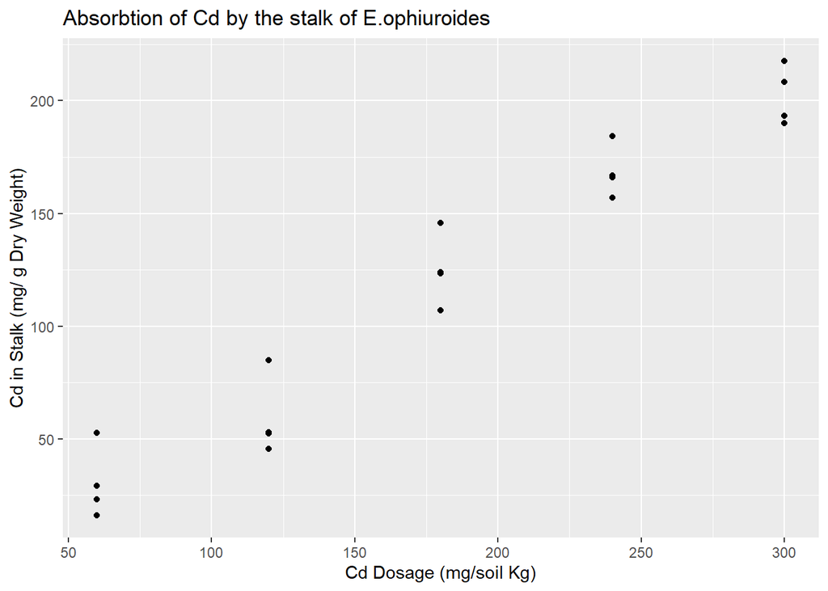

I can easily observe a linear relationship. For which I will propose a mathematical model that will allow me to predict:

Y$_{i}$ = $\hat{\beta}$$_{0}$ + $\hat{\beta}$$_{1}$*$X_{i}$ + $\varepsilon$$_{i}$

Where Y is the RV

$\hat{\beta}$$_{0}$ is the intercept of the model

$\hat{\beta}$$_{1}$ is the slope

$X_{n}$ is the EV

and $\varepsilon$$_{i}$ is the error associated with the model.

The mathematical model is a simple Linear Regression and this can be stated in R as follows:

model1 = lm(Cd$CdStalk ~ Cd$Dosage, data = Cd)

```r
model1 = lm(Cd$CdStalk ~ Cd$Dosage, data = Cd)
summary(model1)
```

```
##
## Call:
## lm(formula = Cd$CdStalk ~ Cd$Dosage, data = Cd)
##
## Residuals:
##     Min      1Q  Median      3Q     Max
## -25.970 -11.220   1.730   7.655  28.680
##
## Coefficients:
##              Estimate Std. Error t value Pr(>|t|)
## (Intercept) -19.03000    8.35547  -2.278   0.0352 *
## Cd$Dosage     0.75583    0.04199  18.001 5.88e-13 ***
## ---
## Signif. codes:  0 '***' 0.001 '**' 0.01 '*' 0.05 '.' 0.1 ' ' 1
##
## Residual standard error: 15.93 on 18 degrees of freedom
## Multiple R-squared:  0.9474, Adjusted R-squared:  0.9445
## F-statistic:   324 on 1 and 18 DF,  p-value: 5.882e-13
```

The summary of the model informs the values of the estimators but these are meaningles if the assumptions of the model are not corroborated

### Assumptions:

#### X is measured without error, Values are determined by the person.

#### Independent Observations, meaning the value of one observation is not influenced by another observation. In other words there shouldn’t be correlation between values.

In order to check the independence of the observations it is necessary to estimate the error of the model:

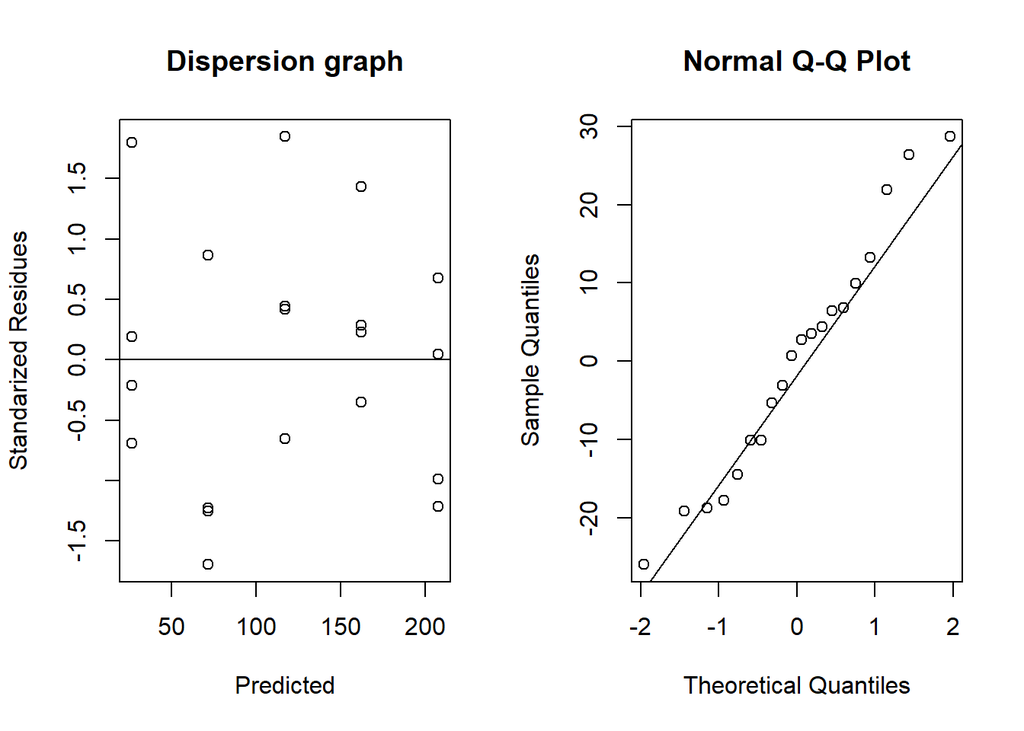

```r
par(mfrow = c(1, 2))
plot(predicted, standard_error, xlab="Predicted", ylab="Standarized Residues",main="Dispersion graph" )
abline(0,0)
qqnorm(error)
qqline(error)
```

In statistics Homoscedasticity is the assumption that the error of the data is distributed normally. I will conduct Shapiro’s Test to test this. To test the Homogeinity of Variance I will conduct a Levene’s Test. Homogeneity of Variance is an assumption that **cannot** not be met, unlike Homoscedasticity that cannot be met but still inform correct statistical values.

```r
shapiro.test(error)
```

```
##
##  Shapiro-Wilk normality test
##
## data:  error
## W = 0.9676, p-value = 0.7035
```

```r
leveneTest(CdTotal,Cd$Dosage)
```

```
## Levene's Test for Homogeneity of Variance (center = median)
##       Df F value Pr(>F)
## group  4  0.7709 0.5607
##       15
```

Since p-value > 0.5 then I do not have to reject the null hypothesisis and the error values also seem to respond to a normal distribution therefore I can conclude that the data of my model is Homoscedastic variance is homogeneously distributed and I can now express the graph and its estimator’s values without the fear of possibly informing incorrectly calculated numbers.

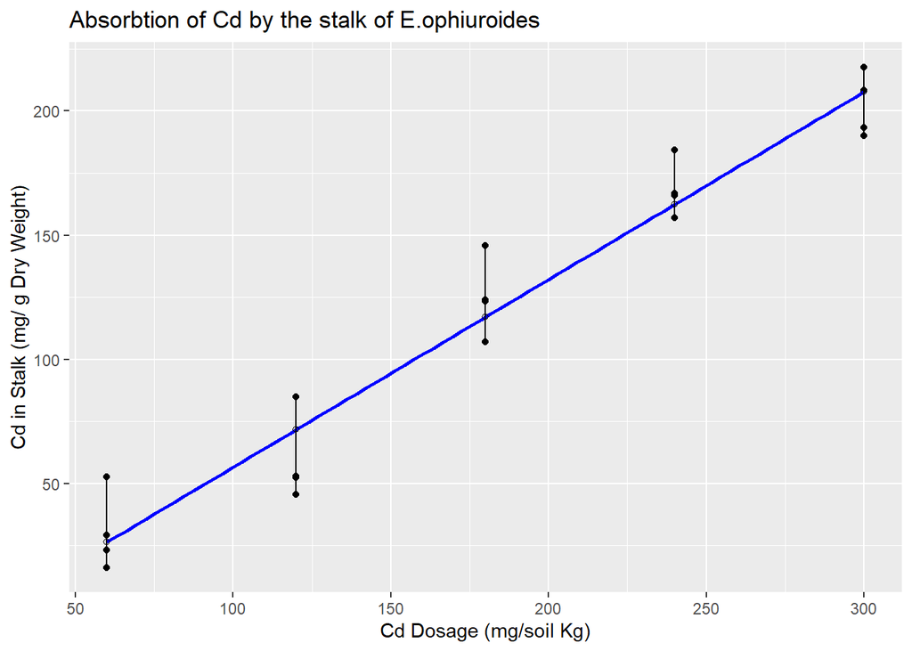

```r
gCd1 + geom_smooth(method = "lm", se = FALSE, color = "blue") +
  geom_segment(aes(xend = Cd$Dosage, yend = predicted)) + ##residues
  geom_point(aes(y = predicted), shape = 1)  ##adds predicted
```

```r
#Determination coefficient
summary(model1)$r.squared
```

```
## [1] 0.9473754
```

0.947, meaning that almost 95% of the variance of the model is explained by this explanatory variable

```r
summary(model1)
```

```
##
## Call:
## lm(formula = Cd$CdStalk ~ Cd$Dosage, data = Cd)
##
## Residuals:
##     Min      1Q  Median      3Q     Max
## -25.970 -11.220   1.730   7.655  28.680
##
## Coefficients:
##              Estimate Std. Error t value Pr(>|t|)
## (Intercept) -19.03000    8.35547  -2.278   0.0352 *
## Cd$Dosage     0.75583    0.04199  18.001 5.88e-13 ***
## ---
## Signif. codes:  0 '***' 0.001 '**' 0.01 '*' 0.05 '.' 0.1 ' ' 1
##
## Residual standard error: 15.93 on 18 degrees of freedom
## Multiple R-squared:  0.9474, Adjusted R-squared:  0.9445
## F-statistic:   324 on 1 and 18 DF,  p-value: 5.882e-13
```